# Practical Machine Learning Course Project

Trevor McCalmont

Saturday, May 23, 2015

# Introduction

In this project we will be using data collected from accelerometers while individuals performed various exercises. The accelerometers were attached to their belt, forearm, arm and dumbbell, and the participants performed exercises both correctly and incorrectly (variable $classe$). A value of $A$ means the exercise was performed correctly, and a value of $B-E$ were four common mistakes.

We will create a prediction model based on 19,600+ observations from the accelerometers, and use this model to predict the quality of exercise from a new data set.

# Upload and Clean the Data

First we upload the data into R and do a few simple manipulations of the data.

```r
trainURL <- "http://d396qusza40orc.cloudfront.net/predmachlearn/pml-training.csv"
testURL <- "http://d396qusza40orc.cloudfront.net/predmachlearn/pml-testing.csv"
trainData <- read.csv(url(trainURL))
testData <- read.csv(url(testURL))
dim(trainData); dim(testData)
```

```
## [1] 19622   160
```

```
## [1]  20 160
```

After viewing the data, we see that Column 1 is simply a row label, which will confuse our models later.

```r
trainData <- trainData[c(-1)]
testData <- testData[c(-1)]
dim(trainData); dim(testData)
```

```
## [1] 19622   159
```

```
## [1]  20 159
```

Next we will look for variables with near zero variance and remove those from the model. They will not have a useful amount of prediction value, so this will not negatively impact the accuracy of our model.

```r
library(caret)
nzv <- nearZeroVar(trainData, saveMetrics=TRUE)
trainData <- trainData[nzv$nzv == FALSE] #train set
testData <- testData[nzv$nzv == FALSE] #test set
dim(trainData); dim(testData)
```

```
## [1] 19622    99
```

```
## [1] 20 99
```

Lastly we will remove variables that have at least 50% missing values. Similarly, these will not add much value to our prediction model.

```r
trainDataCleaned <- trainData
testDataCleaned <- testData

for (i in 1:length(trainData)) {
    if(sum(is.na(trainData[,i]))/nrow(trainData)>=0.5) {
        for (j in 1:length(trainDataCleaned)) {
            if(length(grep(names(trainData[i]), names(trainDataCleaned)[j]))==1) {
                trainDataCleaned <- trainDataCleaned[,-j]
                testDataCleaned <- testDataCleaned[,-j]
            }
        }
    }
}

trainData <- trainDataCleaned
testData <- testDataCleaned

dim(trainData); dim(testData)
```

```
## [1] 19622    58
```

```
## [1] 20 58
```

After cleaning the data set we are down to 58 variables.

# Partition the Data

Next we will partition the training data set. 60% of the data will be allocated to our training data, and 40% of the data will be saved so we can test our models before using the final test data.

```r
set.seed(1717)

inTrain <- createDataPartition(y=trainData$classe, p = 0.6,
                               list=FALSE)
training <- trainData[inTrain,]
testing <- trainData[-inTrain,]
```

# Decision Tree (RPart)

First we’ll look at a prediction model based on a decision tree.

```r
set.seed(1717)
modRPart <- train(classe ~ ., method ="rpart", data=training)
print(modRPart$finalModel)
```

```
## n= 11776
##
## node), split, n, loss, yval, (yprob)
##       * denotes terminal node
##
##   1) root 11776 8428 A (0.28 0.19 0.17 0.16 0.18)
##     2) roll_belt< 130.5 10767 7426 A (0.31 0.21 0.19 0.18 0.11)
##       4) pitch_forearm< -33.65 962    7 A (0.99 0.0073 0 0 0) *
##       5) pitch_forearm>=-33.65 9805 7419 A (0.24 0.23 0.21 0.2 0.12)
##        10) cvtd_timestamp02/12/2011 13:33>=0.5 790  196 A (0.75 0.25 0 0 0) *
##        11) cvtd_timestamp02/12/2011 13:33< 0.5 9015 6939 B (0.2 0.23 0.23 0.21 0.13)
##          22) magnet_dumbbell_z< -88.5 1199  509 A (0.58 0.29 0.046 0.066 0.023) *
##          23) magnet_dumbbell_z>=-88.5 7816 5817 C (0.14 0.22 0.26 0.24 0.15)
##            46) raw_timestamp_part_1< 1.32249e+09 329    0 A (1 0 0 0 0) *
##            47) raw_timestamp_part_1>=1.32249e+09 7487 5488 C (0.1 0.23 0.27 0.25 0.15)
##              94) raw_timestamp_part_1< 1.32249e+09 356    7 B (0.017 0.98 0.0028 0 0) *
##              95) raw_timestamp_part_1>=1.32249e+09 7131 5133 C (0.11 0.19 0.28 0.26 0.16)
##               190) roll_dumbbell< 59.01819 4275 2508 C (0.12 0.13 0.41 0.2 0.14) *
##               191) roll_dumbbell>=59.01819 2856 1861 D (0.085 0.29 0.081 0.35 0.19)
##                 382) magnet_belt_y>=589.5 2459 1484 D (0.099 0.34 0.055 0.4 0.11)
##                   764) magnet_dumbbell_x>=-340.5 678  249 B (0 0.63 0.091 0.063 0.21) *
##                   765) magnet_dumbbell_x< -340.5 1781  849 D (0.14 0.23 0.042 0.52 0.072) *
##                 383) magnet_belt_y< 589.5 397  118 E (0 0.0076 0.24 0.05 0.7) *
##     3) roll_belt>=130.5 1009    7 E (0.0069 0 0 0 0.99) *
```

We can plot this model using the rattle library in R. This will make the decision tree easier to visualize.

```r
library(rattle)
```

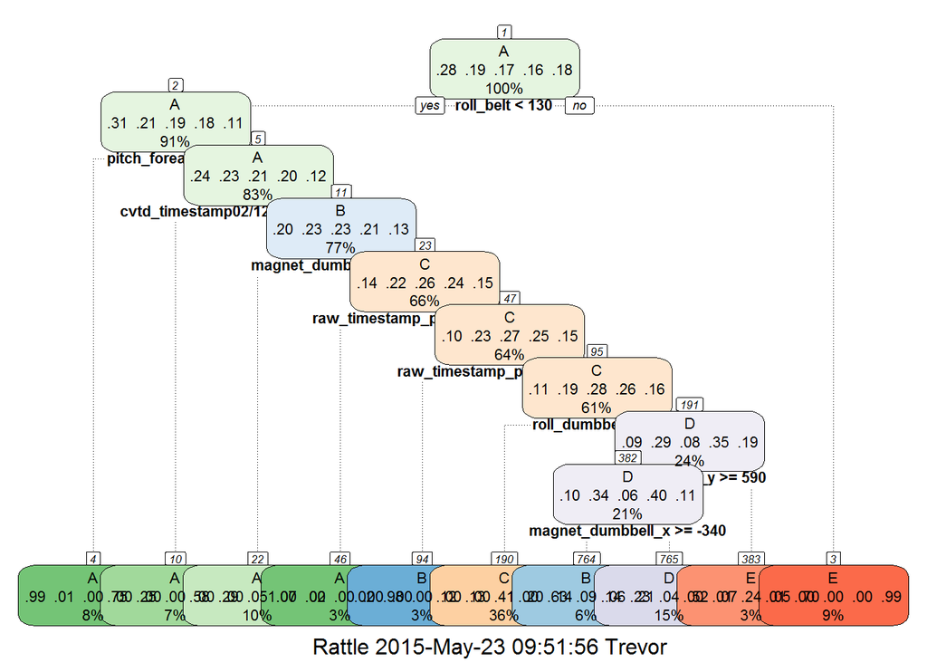

```r
fancyRpartPlot(modRPart$finalModel, cex = 0.7, shadow.offset=0)
```

Next, to check the accuracy of our model we will construct the Confusion Matrix.

```r
predictRPart <- predict(modRPart, newdata=testing)
confusionMatrix(predictRPart, testing$classe)
```

```
## Confusion Matrix and Statistics
##
##           Reference
## Prediction    A    B    C    D    E
##          A 1682  370   43   66   20
##          B    4  508   32   42   93
##          C  378  339 1144  582  413
##          D  161  296   81  574  111
##          E    7    5   68   22  805
##
## Overall Statistics
##
##                Accuracy : 0.6007
##                  95% CI : (0.5898, 0.6115)
##     No Information Rate : 0.2845
##     P-Value [Acc > NIR] : < 2.2e-16
##
##                   Kappa : 0.497
##  Mcnemar's Test P-Value : < 2.2e-16
##
## Statistics by Class:
##
##                      Class: A Class: B Class: C Class: D Class: E
## Sensitivity            0.7536  0.33465   0.8363  0.44635   0.5583
## Specificity            0.9111  0.97298   0.7357  0.90107   0.9841
## Pos Pred Value         0.7712  0.74816   0.4006  0.46934   0.8875
## Neg Pred Value         0.9029  0.85908   0.9551  0.89250   0.9082
## Prevalence             0.2845  0.19347   0.1744  0.16391   0.1838
## Detection Rate         0.2144  0.06475   0.1458  0.07316   0.1026
## Detection Prevalence   0.2780  0.08654   0.3640  0.15588   0.1156
## Balanced Accuracy      0.8323  0.65381   0.7860  0.67371   0.7712
```

We can see from the Confusion Matrix that the accuracy of this model was very close to 60%. That’s not terrible given that the variable $classe$ has five potential outcomes, but we can do better.